# ISoP Student Metrics Munch (M&M) Newsletter

## **ISoP Student Metrics Munch (M&M) Newsletter**

2021-02-06

Hello, Aspirant Pharmacometricians!

We are very excited to present our *third* issue of our newsletter!

# Contents

> **Regulatory consideration**

> **Panademic Graduations!!**

> **Looking for Jobs/Internships?**

> **Join the ISoP/ISoP Student Community**

### **Regulatory consideration**

**Shamir Kalaria, Ph.D.**, Regulatory consideration in Clinical pharmacology.

**February 11, 2021 (Thursday) 12:00 -1:00 pm CST** [Join the Zoom](https://tennessee.zoom.us/j/95010306395)

### **Panademic Graduations!!**

Yi Ting (Kayla) Lien, PhD  
Pharmaceutics, University of Florida

Tanaya Vaidya, PhD  
Pharmaceutics, University of Florida

Ashwin Karanam, PharmD, PhD  
Experimental and Clinical Pharmacology, University of Minnesota

Abhishek Sathe, PhD  
Experimental and Clinical Pharmacology, University of Minnesota

Santosh Wagh, PhD  
Pharmaceutical Sciences, University of Tennessee Health Science Center

### **Looking for Jobs/Internships?**

Jobs and internships in Pharmacometrics/ Clinical Pharmacology around the globe

[View the lists](https://docs.google.com/document/d/1ZCmS4n4Zme9-XzfvQ1j_c1mRWU3vPjRWiNy1B85SUHk/edit)

### **Join the ISoP/ISoP Student Community**

[Join as a ISoP Member](http://go-isop.org/benefits/)

[Join the ISoP student Community](https://isop-student-community.github.io/isop-student-community/vol.html)

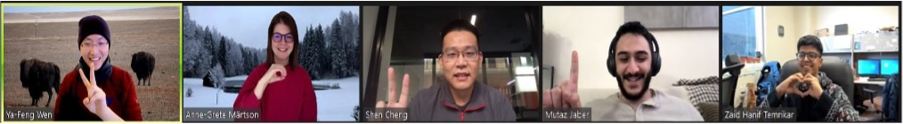

THE COMMUNICATION TEAM WISHED EVERYOE A SAFE AND HEALTHY HAPPY NEWYEAR

**Thank you!**

*ISoP Student Communication team*

- If you want to be added to the ISoP Communications email list, please contact Zaid Temrikar: ztemrika@uthsc.edu
- If you have ideas for events, please email Zaid Temrikar: ztemrika@uthsc.edu or Anne-Grete Märtson: a.martson@umcg.nl